# Report on association of systolic blood pressure and death with data from the Framingham study

## Visual representation of systolic blood pressure

Fig-1 illustrates the systolic blood pressure in the framingham study population. The figure shows evidence that the systolic blood pressure is not normally distributed and that the data is skewed in both groups. When performing the Shapiro test in both groups the p-value is 2.2e-16, meaning that the data is not normally distributed. This is also visualized by the QQplots shown in Fig-2 because the sample quantiles differ from the theoretical quantiles. In the boxplots Fig-3 it is visualized that the systolic blood pressure in the deceased individuals were higher then the one in surviving individuals.

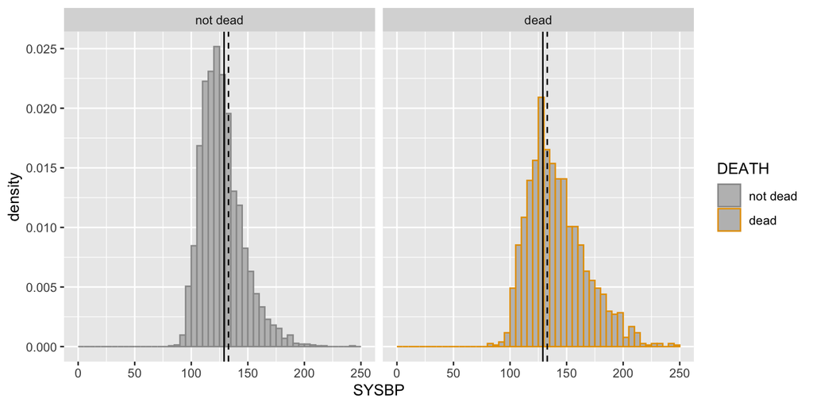

```r
# Plot distribution of blood pressure separately for patients that died and patients that did not
ggplot(framData_base, aes(x = SYSBP, color = DEATH)) +
  geom_histogram(aes(y = after_stat(density)), breaks = seq(0, 250, by = 5), fill = "grey") +
  geom_vline(aes(xintercept = median(SYSBP)), color = "black", linetype = "solid") +
  geom_vline(aes(xintercept = mean(SYSBP)), color = "black", linetype = "dashed") +
  facet_wrap(~DEATH) +
  scale_color_manual(values = c("#999999", "#E69F00"))
```

**Shapiro test for surviving individuals:**

```r
# Shapiro test for surviving individuals
shapiro_survived <- shapiro.test(framData_base$SYSBP[framData_base$DEATH == "not dead"])
shapiro_survived
```

```
    Shapiro-Wilk normality test

data:  framData_base$SYSBP[framData_base$DEATH == "not dead"]
W = 0.94853, p-value < 2.2e-16
```

**Shapiro test for deceased individuals:**

```r
# Shapiro test for deceased individuals
shapiro_deceased <- shapiro.test(framData_base$SYSBP[framData_base$DEATH == "dead"])
shapiro_deceased
```

```
    Shapiro-Wilk normality test

data:  framData_base$SYSBP[framData_base$DEATH == "dead"]
W = 0.95532, p-value < 2.2e-16
```

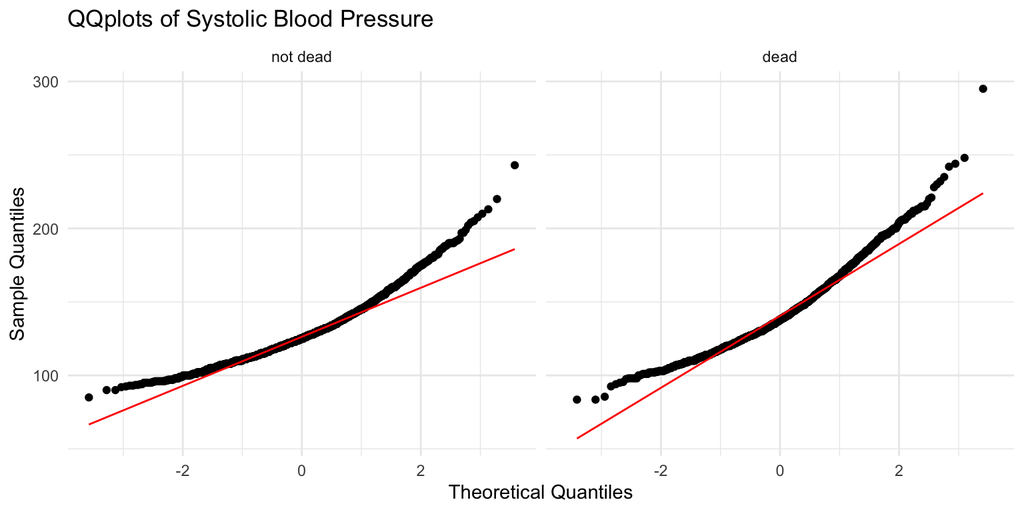

QQplots of the systolic blood pressure of both groups (surviving and deceased).

```r
# QQplot for surviving and deceased individuals
ggplot(framData_base, aes(sample = SYSBP)) +
  geom_qq(color = "black") +
  geom_qq_line(color = "red") +
  facet_wrap(~ DEATH) +
  labs(title = "QQplots of Systolic Blood Pressure",
       x = "Theoretical Quantiles",
       y = "Sample Quantiles") +
  theme_minimal()
```

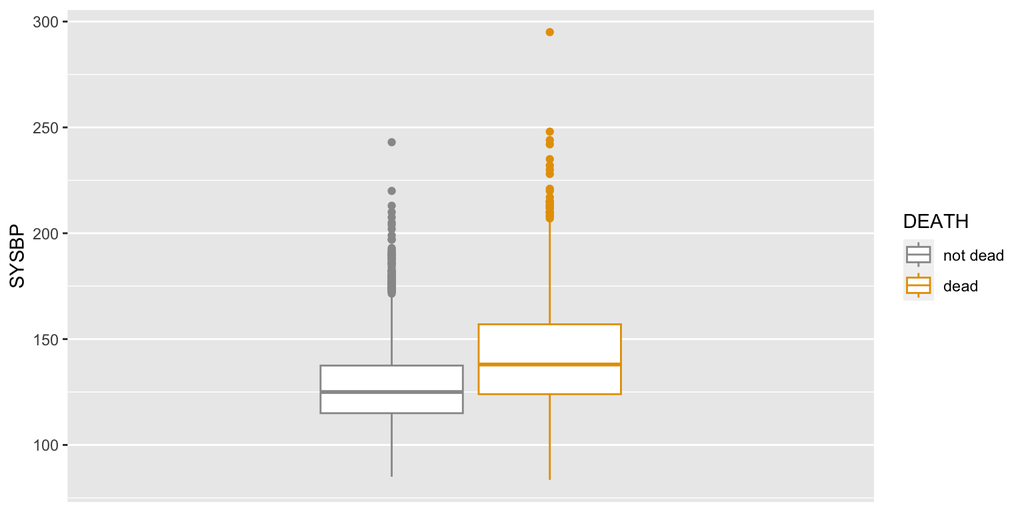

```r
# Boxplot with ggplot2
#| label: Fig-3
#| fig-cap: "Box plots of the systolic blood pressure of both groups (surviving and deceased)."
#| fig-width: 8
#| fig-height: 4
ggplot(framData_base, aes(y = SYSBP, groups = DEATH, color = DEATH)) +
  geom_boxplot() +
  scale_x_discrete() +
  scale_color_manual(values = c("#999999", "#E69F00"))
```

## Wilcoxon test

```r
# Wilcoxon test
data_dead <- subset(framData_base, DEATH == "dead")
data_not_dead <- subset(framData_base, DEATH == "not dead")

wilcox_result <- wilcox.test(data_dead$SYSBP, data_not_dead$SYSBP, alternative = "two.sided", correct = TRUE)
# Print results
cat("Wilcoxon Test Result:")
print(wilcox_result)
```

[output not shown]

## Conclusion

The descriptive statistics of systolic blood pressure for the group that survived and the group that died during the study period have been calculated. These statistics provide an overview of the central tendency, dispersion, and range of systolic blood pressure in each group. There is evidence that the systolic blood pressure in the Framingham study population was higher in deceased individuals compared to the individuals who survived. The Wilcoxon test was chosen for the analysis due to the non-normal distribution of systolic blood pressure. However, given the large sample size of 4434 individuals, a t-test would have also been appropriate. It is important to note that from an epidemiological perspective, the association between high blood pressure and death in this cohort study may not be well chosen because the study does not control why death occurred.